# 回帰分析（交差項）模範解答・解説

### 5.2 `msm` パッケージによる可視化

・前節では2つの当選回数それぞれの限界効果を示したが、統計的な有意性は不明  
・2 本の回帰直線の傾きの違いは、統計的にも意味のある違いなのだろうか？  
・交差項の効果は偶然得られたものではないのか（= 統計的に有意なのか）？  
・moderator 変数 (`previous`) の最小値と最大値を確かめる

```r
summary(hr2012$previous)
```

```
   Min. 1st Qu.  Median    Mean 3rd Qu.    Max.
  0.000   0.000   1.000   1.563   2.000  15.000
```

```r
model$coef
```

```
   (Intercept)          exppv       previous exppv:previous
    6.14172995     0.72309259     5.45887676    -0.09067987
```

```r
at.previous <- seq(0, 15, 3) # mini - max まで 3間隔で区切る
slopes <- model$coef[2] + model$coef[4]*at.previous
                    # exppv の傾きの総合値 (slopes) を計算する
                    # [2] は二つ目の係数、[4] は四つ目の係数という意味
slopes　            # 結果を表示する
```

```
[1]  0.72309259  0.45105298  0.17901337 -0.09302624 -0.36506586 -0.63710547
```

・`delta method` を使ってこれらの 6 つの影響力 (= `slopes`) の標準誤差 (standard error) を推定  
→95%信頼区間が計算できる  
・`delta method`コマンドを使うために `msm package`をインストールする

```r
library(msm)
```

・`previous` の規模ごとに得られた 6 つの影響力。 (sloples)とその標準誤差を計算し、図で表す。  
・95% 信頼区間 (upper, lower) を表示。

```r
estmean <-coef(model)
var<-vcov(model)

SEs <- rep(NA, length(at.previous))

for (i in 1:length(at.previous)){
    j <- at.previous[i]
    SEs[i] <- deltamethod (~ (x2) + (x4)*j, estmean, var)　# slopes の 標準誤差
}

upper <- slopes + 1.96*SEs
lower <- slopes - 1.96*SEs

cbind(at.previous, slopes, upper, lower)
```

```
     at.previous      slopes       upper      lower
[1,]           0  0.72309259  0.78124102  0.6649441
[2,]           3  0.45105298  0.50286096  0.3992450
[3,]           6  0.17901337  0.26039833  0.0976284
[4,]           9 -0.09302624  0.03026032 -0.2163128
[5,]          12 -0.36506586 -0.19650648 -0.5336252
[6,]          15 -0.63710547 -0.42202044 -0.8521905
```

・`at.previous` は当選回数を mini (0) から max (15)まで 3 ずつ増やした場合の当選回数  
・`slopes` は 6 つの当選回数それぞれの場合において、`exppv` が `voteshare` に及ぼす影響力の大きさ（＝傾き）  
・[2, ] と `slopes` に囲まれた値 (0.45105298)  
→ 当選回数 (`at.previous`) が 3 回の時に、説明変数 (`exppv`) が応答変数 (`voteshare`) に与える影響力（回帰線の傾き）  
・[3, ] と `slopes` に囲まれた値 (0.17901337)  
→ 当選回数 (`at.previous`) が 6 回の時に、説明変数 (`exppv`) が応答変数 (`voteshare`) に与える影響力（回帰線の傾き）  
・`upper` と `lower` は95% 信頼区間

当選回数が**少ない**場合 (0 回) の場合の回帰式

$\mathrm{\widehat{voteshare}\ = 6.14 + (0.72 - 0.09previous) exppv + 5.46previous}$

$\mathrm{= 6.14 + 0.72exppv}$

・当選回数 0 回の時に `exppv` が `voteshare` に与える影響力・・・0.72

当選回数が**多い**場合 (4 回: mean + 1 sd) の場合の回帰式

$\mathrm{\widehat{voteshare}\ = 6.14 + (0.72 - 0.09*4) exppv + 5.46*4}$

・当選回数 4 回の時に `exppv` が `voteshare` に与える影響力・・・0.36  
・当選回数 4 回 **(slopes = 0.36)** は当選回数 3 回 (slope = 0.45105298)と当選回数 6 回 (slope = 0.17901337) に挟まれた値

・当選回数 (`previous`)の値が大きくなるにつれて、$slopes$ の値が徐々に小さくなっていることがわかる。  
・`previous` を x 軸、`exppv` が `voteshare` に与える影響力 (`slopes`) を y 軸にグラフを描く

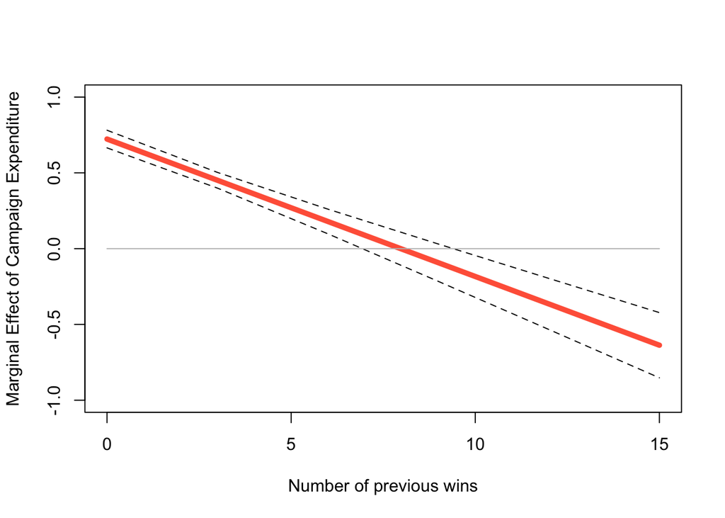

```r
plot(at.previous, slopes, type = "l", lwd = 5, col = "tomato", lty = 1,
     ylim = c(-1, 1), xlab = "Number of previous wins",
     ylab = "Marginal Effect of Campaign Expenditure")
points(at.previous, upper, type = "l", lty = 2)
points(at.previous, lower, type = "l", lty = 2)
points(at.previous, rep(0, length(at.previous)), type = "l", col = "gray")
```

**結論：**  
(1) 当選回数が増えるにつれて、得票率に与える選挙費用の影響は小さくなっている  
(2) 統計的に有意なのは当選回数が0回から6回と10回以降だけ  
(3) 当選回数が 7回から9回の候補者は統計的に有意ではない

### 5.3 おまけ1： `interplot` パッケージによる可視化

```r
library(interplot)
```

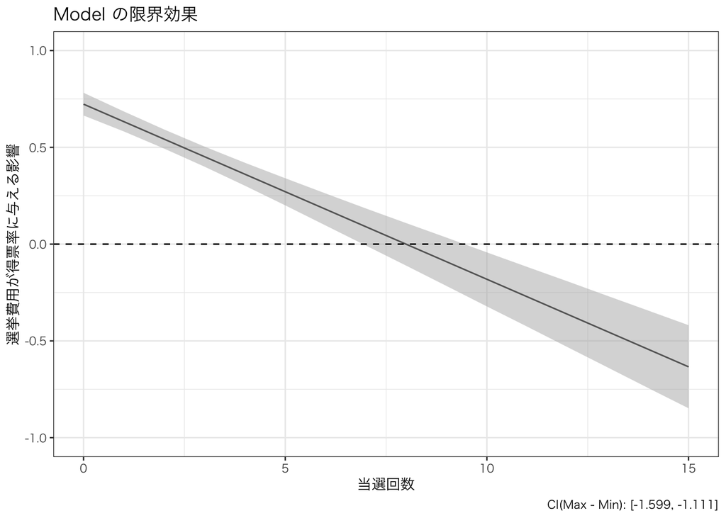

```r
omake1 <- interplot(m = model,
          var1 = "exppv",
          var2 = "previous") +
labs(x = "当選回数",
     y = "選挙費用が得票率に与える影響") +
  ggtitle('Model の限界効果') +
  geom_hline(yintercept = 0, linetype = 2) +
  ylim(-1, 1)

omake1
```

### 5.4 おまけ2： `margins` パッケージによる可視化

```r
library(margins)
```

```r
omake2 <- cplot(model,               # 推定するモデルを指定
                   x = "previous",  # 調整変数を指定
                   dx = "exppv", 　 # 主要な説明を指定
                   what = "effect", # 限界効果の計算を指定
                   n = 16,           # previous を分類する数を指定（任意）
                   draw = FALSE)    # グラフを表示しない指定
omake2
```

```
   xvals   yvals   upper   lower factor
  0.0000  0.7231  0.7812  0.6649  exppv
  1.0000  0.6324  0.6837  0.5811  exppv
  2.0000  0.5417  0.5907  0.4927  exppv
  3.0000  0.4511  0.5029  0.3992  exppv
  4.0000  0.3604  0.4194  0.3014  exppv
  5.0000  0.2697  0.3389  0.2004  exppv
  6.0000  0.1790  0.2604  0.0976  exppv
  7.0000  0.0883  0.1830 -0.0064  exppv
  8.0000 -0.0023  0.1064 -0.1111  exppv
  9.0000 -0.0930  0.0303 -0.2163  exppv
 10.0000 -0.1837 -0.0455 -0.3219  exppv
 11.0000 -0.2744 -0.1211 -0.4277  exppv
 12.0000 -0.3651 -0.1965 -0.5336  exppv
 13.0000 -0.4557 -0.2718 -0.6397  exppv
 14.0000 -0.5464 -0.3469 -0.7459  exppv
 15.0000 -0.6371 -0.4220 -0.8522  exppv
```

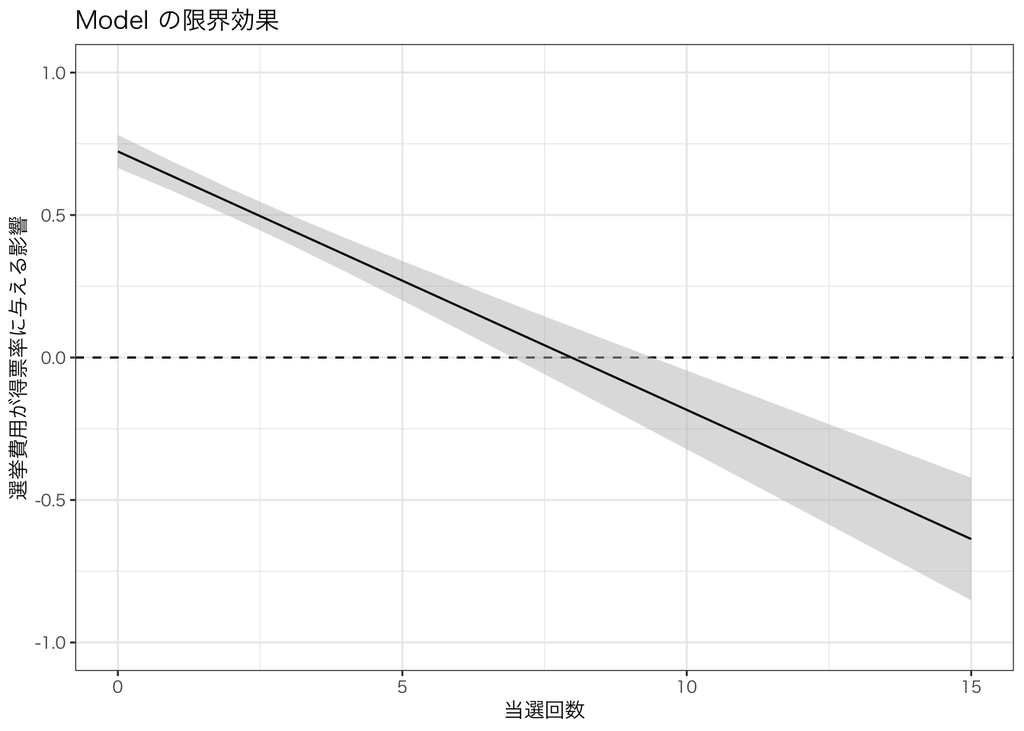

```r
omake2 <- omake2  %>%
  ggplot(aes(x = xvals,
             y = yvals,
             ymin = lower,
             ymax = upper)) +
  geom_hline(yintercept = 0, linetype = 2) +
  geom_ribbon(alpha = 0.5, fill = "gray") +
  geom_line() +
  labs(x = "当選回数",
     y = "選挙費用が得票率に与える影響") +
  ggtitle('Model の限界効果') +
  ylim(-1, 1)

omake2
```